# 6_Sentiment_analys.R

helianateixeira

2021-10-19

## Linguistic analysis - part C

author: Heliana Teixeira date: 28-07-2021 code adapted from book “Text Mining with R: A Tidy Approach” at https://www.tidytextmining.com/tidytext.html

Using BBNJ dataset, Considering key Messages by Categories (#6) within SWOT levels (#4), through time (Negotiation.phase #3) This script applies keyword extraction techniques to analyse plain text and perform sentiment analysis. Clear R workspace

```r
rm(list = ls())

#### load packages ----
library(here)
library(tidyr)
library (tidytext)
library(tidyverse)
library(scales) # to visualise
#### load packages ----
library(here)
library(tidyr)
library (tidytext)
library(tidyverse)
library(scales) # to visualise

#### load data ----
here::here()
```

```
## [1] "/Users/helianateixeira/OneDrive - Universidade de Aveiro/Rdir/TextMining"
```

```r
Fname.dat_1 <- (here("Data", "MessageTidy_SWOT.csv")) #edit file name
data_1 <- read.csv(file = Fname.dat_1, header = TRUE, sep = ",", dec =".")

Fname.dat_2 <- (here("Data", "MessageTidy_Cats.csv")) #edit file name
data_2 <- read.csv(file = Fname.dat_2, header = TRUE, sep = ",", dec =".")

Fname.dat_3 <- (here("Data", "MessageTidy_SWOTCats.csv")) #edit file name
data_3 <- read.csv(file = Fname.dat_3, header = TRUE, sep = ",", dec =".")
```

### 2. Sentiment analysis

There are variety of methods and dictionaries for evaluating the opinion or emotion in text. binary positive and negative categories

```r
get_sentiments("bing")
```

```
## # A tibble: 6,786 x 2
##    word        sentiment
##    <chr>       <chr>
##  1 2-faces     negative
##  2 abnormal    negative
##  3 abolish     negative
##  4 abominable  negative
##  5 abominably  negative
##  6 abominate   negative
##  7 abomination negative
##  8 abort       negative
##  9 aborted     negative
## 10 aborts      negative
## # … with 6,776 more rows
```

assigns words with a score that runs between -5 and 5, with negative scores indicating negative sentiment and positive scores indicating positive sentiment

```r
#install.packages("textdata")
library(textdata)
get_sentiments("afinn")
```

```
## # A tibble: 2,477 x 2
##    word       value
##    <chr>      <dbl>
##  1 abandon       -2
##  2 abandoned     -2
##  3 abandons      -2
##  4 abducted      -2
##  5 abduction     -2
##  6 abductions    -2
##  7 abhor         -3
##  8 abhorred      -3
##  9 abhorrent     -3
## 10 abhors        -3
## # … with 2,467 more rows
```

categorizes words in a binary fashion (“yes”/“no”) into categories of positive, negative, anger, anticipation, disgust, fear, joy, sadness, surprise, and trust.

```r
get_sentiments("nrc")
```

```
## # A tibble: 13,875 x 2
##    word        sentiment
##    <chr>       <chr>
##  1 abacus      trust
##  2 abandon     fear
##  3 abandon     negative
##  4 abandon     sadness
##  5 abandoned   anger
##  6 abandoned   fear
##  7 abandoned   negative
##  8 abandoned   sadness
##  9 abandonment anger
## 10 abandonment fear
## # … with 13,865 more rows
```

https://saifmohammad.com/WebPages/NRC-Emotion-Lexicon.htm

```r
library(stringr)
library(dplyr)
```

### Sentiment through the SWOT levels

bing lexicon

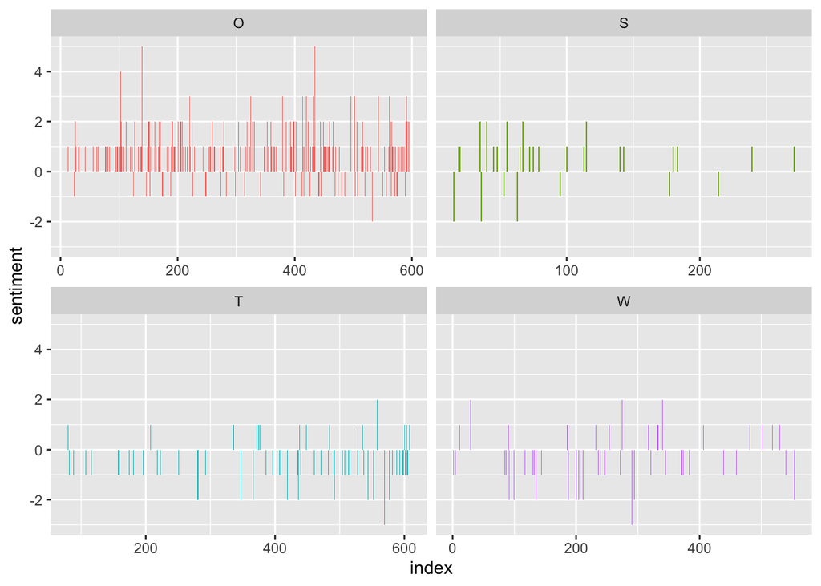

```r
SWOT.sentim <- data_1 %>%
  inner_join(get_sentiments("bing"), by = c("Message" = "word")) %>%
  count(SWOT, index= msg.number,sentiment) %>%
  pivot_wider(names_from = sentiment, values_from = n, values_fill = 0) %>%
  mutate(sentiment = positive - negative)

library(ggplot2)
ggplot(SWOT.sentim, aes(index, sentiment, fill = SWOT)) +
  geom_col(show.legend = FALSE) +
  facet_wrap(~SWOT, ncol = 2, scales = "free_x")
```

afinn lexicon

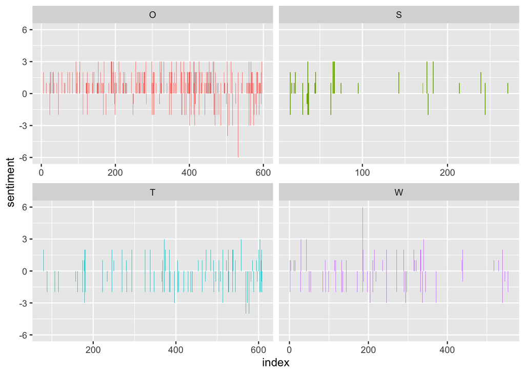

```r
SWOT.sentim2 <- data_1 %>%
  inner_join(get_sentiments("afinn"), by = c("Message" = "word")) %>%
  count(SWOT, index= msg.number, value) %>%
  mutate(sentiment = value)

ggplot(SWOT.sentim2, aes(index, sentiment, fill = SWOT)) +
  geom_col(show.legend = FALSE) +
  facet_wrap(~SWOT, ncol = 2, scales = "free_x")
```

positive vs negative

```r
library(reshape2)
```

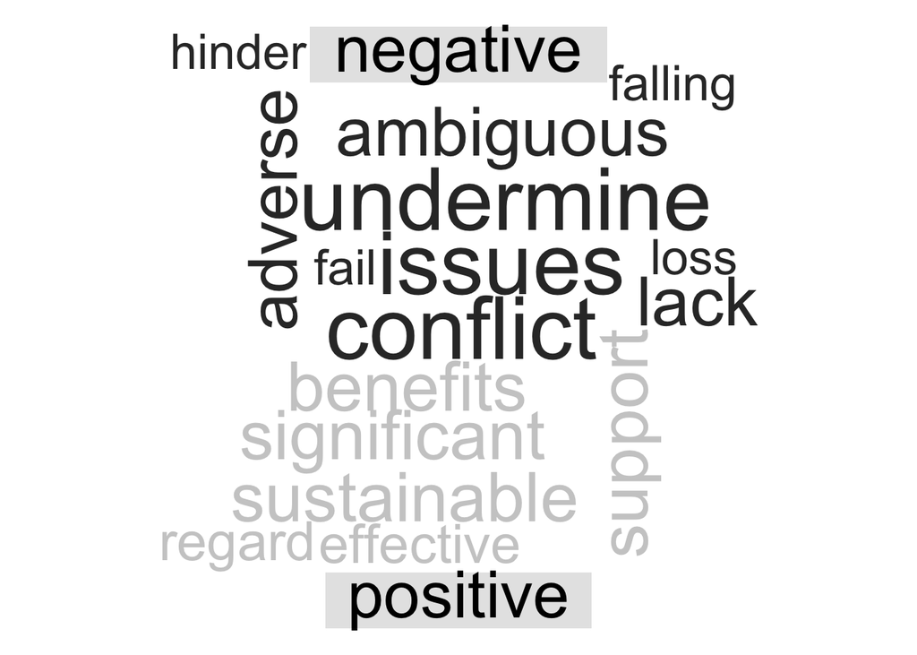

```r
library(wordcloud)
data_1 %>%
  group_by(SWOT)%>%
  inner_join(get_sentiments("bing"),by = c("Message" = "word")) %>%
  count(Message, sentiment, sort = TRUE) %>%
  acast(Message ~ sentiment, value.var = "n", fill = 0) %>%
  comparison.cloud(colors = c("gray20", "gray80"),
                   max.words = 40)
```

### Sentiment through the Categories

bing lexicon

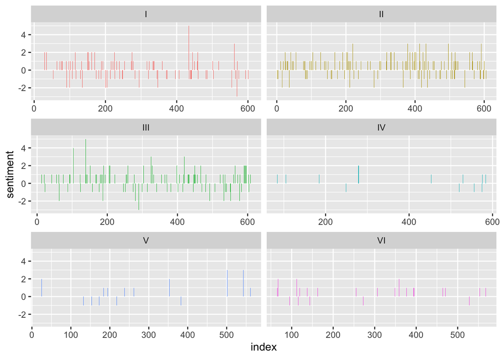

```r
Cats.sentim <- data_2 %>%
  inner_join(get_sentiments("bing"), by = c("Message" = "word")) %>%
  count(Category, index= msg.number,sentiment) %>%
  pivot_wider(names_from = sentiment, values_from = n, values_fill = 0) %>%
  mutate(sentiment = positive - negative)

library(ggplot2)
ggplot(Cats.sentim, aes(index, sentiment, fill = Category)) +
  geom_col(show.legend = FALSE) +
  facet_wrap(~Category, ncol = 2, scales = "free_x")
```

afinn lexicon

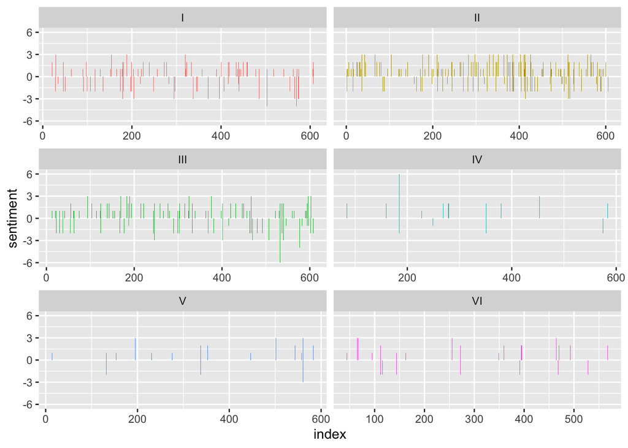

```r
Cats.sentim2 <- data_2 %>%
  inner_join(get_sentiments("afinn"), by = c("Message" = "word")) %>%
  count(Category, index= msg.number, value) %>%
  mutate(sentiment = value)

ggplot(Cats.sentim2, aes(index, sentiment, fill = Category)) +
  geom_col(show.legend = FALSE) +
  facet_wrap(~Category, ncol = 2, scales = "free_x")
```

positive vs negative

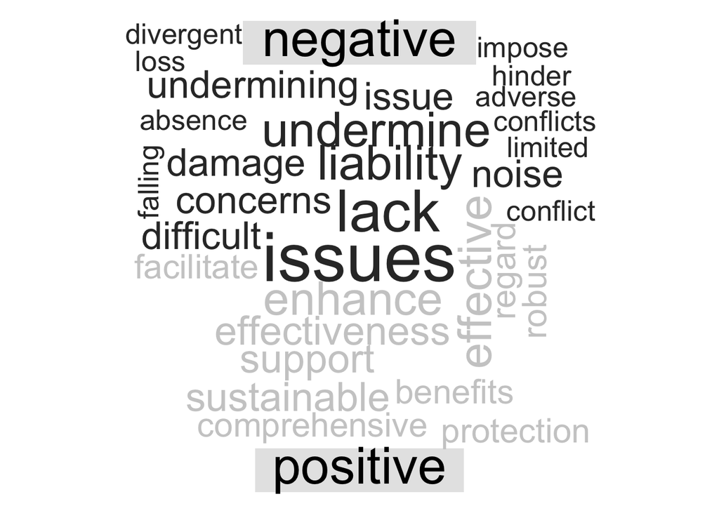

```r
library(reshape2)
library(wordcloud)
data_2 %>%
  group_by(Category)%>%
  inner_join(get_sentiments("bing"),by = c("Message" = "word")) %>%
  count(Message, sentiment, sort = TRUE) %>%
  acast(Message ~ sentiment, value.var = "n", fill = 0) %>%
  comparison.cloud(colors = c("gray20", "gray80"),
                   max.words = 40)
```

### Sentiment through the Negotiation phases

bing lexicon

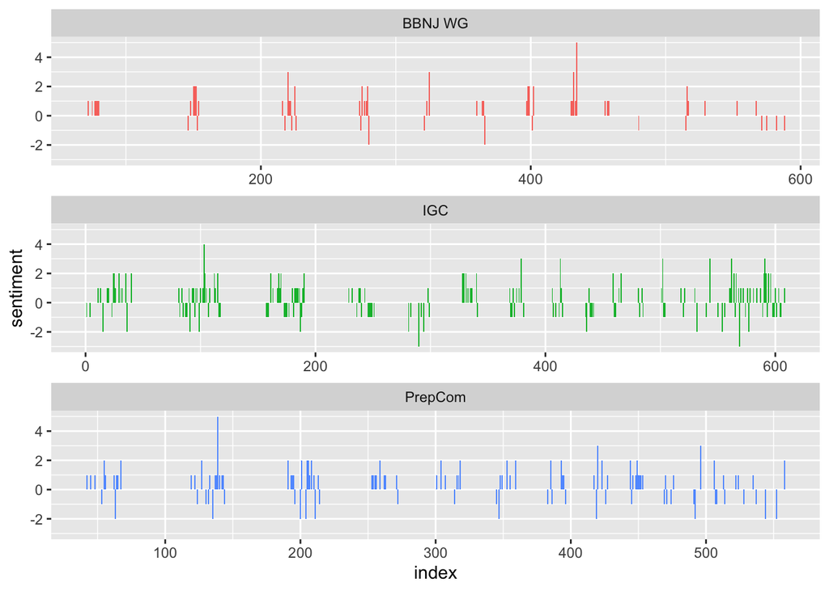

```r
time.sentim <- data_3 %>%
  inner_join(get_sentiments("bing"), by = c("Message" = "word")) %>%
  count(Negotiation.phase, index= msg.number,sentiment) %>%
  pivot_wider(names_from = sentiment, values_from = n, values_fill = 0) %>%
  mutate(sentiment = positive - negative)

library(ggplot2)
ggplot(time.sentim, aes(index, sentiment, fill = Negotiation.phase)) +
  geom_col(show.legend = FALSE) +
  facet_wrap(~Negotiation.phase, ncol = 1, scales = "free_x")
```

afinn lexicon

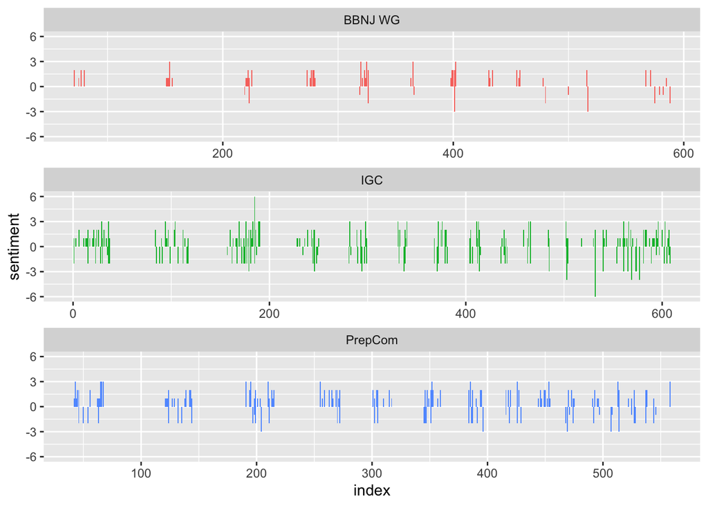

```r
time.sentim2 <- data_3 %>%
  inner_join(get_sentiments("afinn"), by = c("Message" = "word")) %>%
  count(Negotiation.phase, index= msg.number, value) %>%
  mutate(sentiment = value)

ggplot(time.sentim2, aes(index, sentiment, fill = Negotiation.phase)) +
  geom_col(show.legend = FALSE) +
  facet_wrap(~Negotiation.phase, ncol = 1, scales = "free_x")
```

positive vs negative

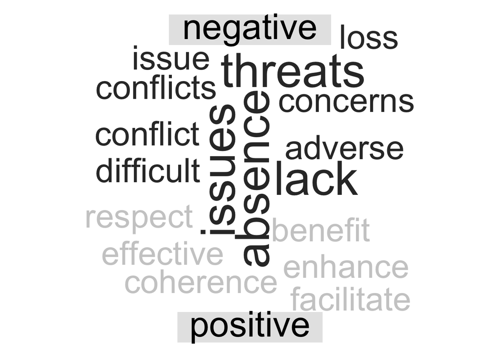

```r
library(reshape2)
library(wordcloud)
data_3 %>%
  group_by(Negotiation.phase)%>%
  inner_join(get_sentiments("bing"),by = c("Message" = "word")) %>%
  count(Message, sentiment, sort = TRUE) %>%
  acast(Message ~ sentiment, value.var = "n", fill = 0) %>%
  comparison.cloud(colors = c("gray20", "gray80"),
                   max.words = 40)
```

positive vs negative in all messages together

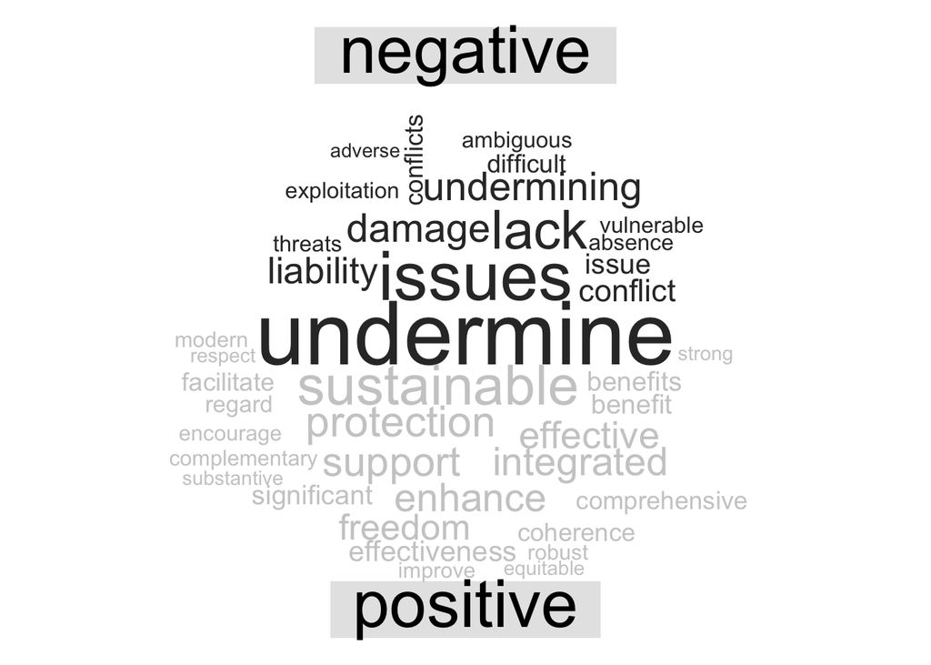

```r
data_1%>%
  inner_join(get_sentiments("bing"),by = c("Message" = "word")) %>%
  count(Message, sentiment, sort = TRUE) %>%
  acast(Message ~ sentiment, value.var = "n", fill = 0) %>%
  comparison.cloud(colors = c("gray20", "gray80"),
                   max.words = 40)
```

Turn the R script into markdown output: Cmd + Shift + K